# Project IV

## EDA of Red Wine Dataset

*by Xiaopeng Hu*

========================================================

### Quick review of dataset

```
##  [1] X                    fixed.acidity        volatile.acidity
##  [4] citric.acid          residual.sugar       chlorides
##  [7] free.sulfur.dioxide  total.sulfur.dioxide density
## [10] pH                   sulphates            alcohol
## [13] quality
## <0 rows> (or 0-length row.names)
```

```
## 'data.frame':    1599 obs. of  13 variables:
##  $ X                   : int  1 2 3 4 5 6 7 8 9 10 ...
##  $ fixed.acidity       : num  7.4 7.8 7.8 11.2 7.4 7.4 7.9 7.3 7.8 7.5 ...
##  $ volatile.acidity    : num  0.7 0.88 0.76 0.28 0.7 0.66 0.6 0.65 0.58 0.5 ...
##  $ citric.acid         : num  0 0 0.04 0.56 0 0 0.06 0 0.02 0.36 ...
##  $ residual.sugar      : num  1.9 2.6 2.3 1.9 1.9 1.8 1.6 1.2 2 6.1 ...
##  $ chlorides           : num  0.076 0.098 0.092 0.075 0.076 0.075 0.069 0.065 0.073 0.071 ...
##  $ free.sulfur.dioxide : num  11 25 15 17 11 13 15 15 9 17 ...
##  $ total.sulfur.dioxide: num  34 67 54 60 34 40 59 21 18 102 ...
##  $ density             : num  0.998 0.997 0.997 0.998 0.998 ...
##  $ pH                  : num  3.51 3.2 3.26 3.16 3.51 3.51 3.3 3.39 3.36 3.35 ...
##  $ sulphates           : num  0.56 0.68 0.65 0.58 0.56 0.56 0.46 0.47 0.57 0.8 ...
##  $ alcohol             : num  9.4 9.8 9.8 9.8 9.4 9.4 9.4 10 9.5 10.5 ...
##  $ quality             : int  5 5 5 6 5 5 5 7 7 5 ...
```

There are 13 variables and 1599 observations in this dataset. The first variable X is apparently the series of all observations and will not be included in following analysis. For other variables, “quality” is the dependent variable, so there are 11 independent variables about the physical and chemical properties of wines, e.g., “fixed.acidity”, “volatile.acidity”, “citric.acid”, “residual.sugar”, “chlorides”, “free.sulfur.dioxide”, “total.sulfur.dioxide”, “density”, “pH”, “sulphates”, “alcohol”. The dependent variable “quality” has integer attribute, it could also be considered as a categorical variable. All independent variables have numeric attribute,

This is a completed dataser without missing value or NA.

# Univariate Plots Section

In following analysis, simple statistic analysis are performed on each of the 12 variables, then adjusted binwidths are employed accordingly to produce histogram plot with more details.

```
##    Min. 1st Qu.  Median    Mean 3rd Qu.    Max.
##   3.000   5.000   6.000   5.636   6.000   8.000
```

```
##
##           3           4           5           6           7           8
## 0.006253909 0.033145716 0.425891182 0.398999375 0.124452783 0.011257036
```

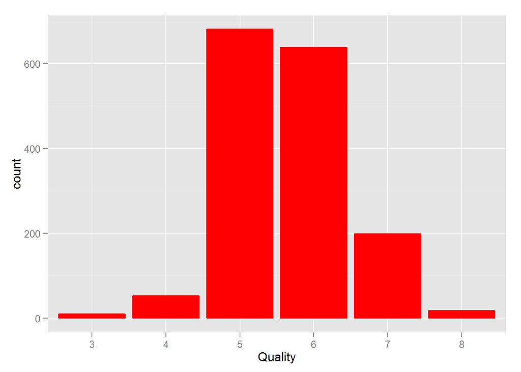

```
##    Min. 1st Qu.  Median    Mean 3rd Qu.    Max.
##    4.60    7.10    7.90    8.32    9.20   15.90
```

```
##    Min. 1st Qu.  Median    Mean 3rd Qu.    Max.
##  0.1200  0.3900  0.5200  0.5278  0.6400  1.5800
```

```
##    Min. 1st Qu.  Median    Mean 3rd Qu.    Max.
##   0.000   0.090   0.260   0.271   0.420   1.000
```

```
##    Min. 1st Qu.  Median    Mean 3rd Qu.    Max.
##   2.740   3.210   3.310   3.311   3.400   4.010
```

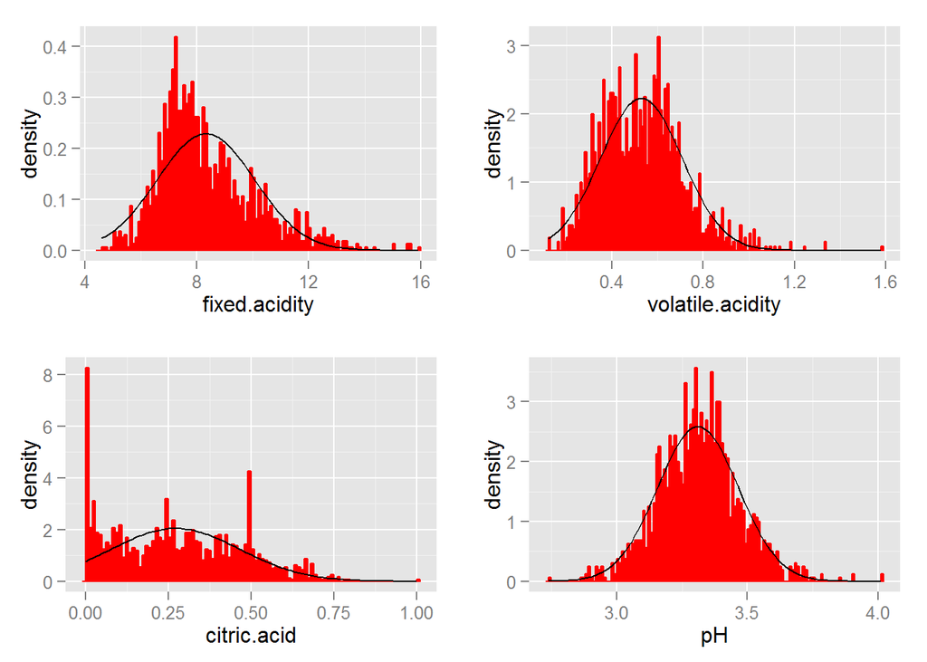

```
##    Min. 1st Qu.  Median    Mean 3rd Qu.    Max.
##   0.900   1.900   2.200   2.539   2.600  15.500
```

```
##    Min. 1st Qu.  Median    Mean 3rd Qu.    Max.
## 0.01200 0.07000 0.07900 0.08747 0.09000 0.61100
```

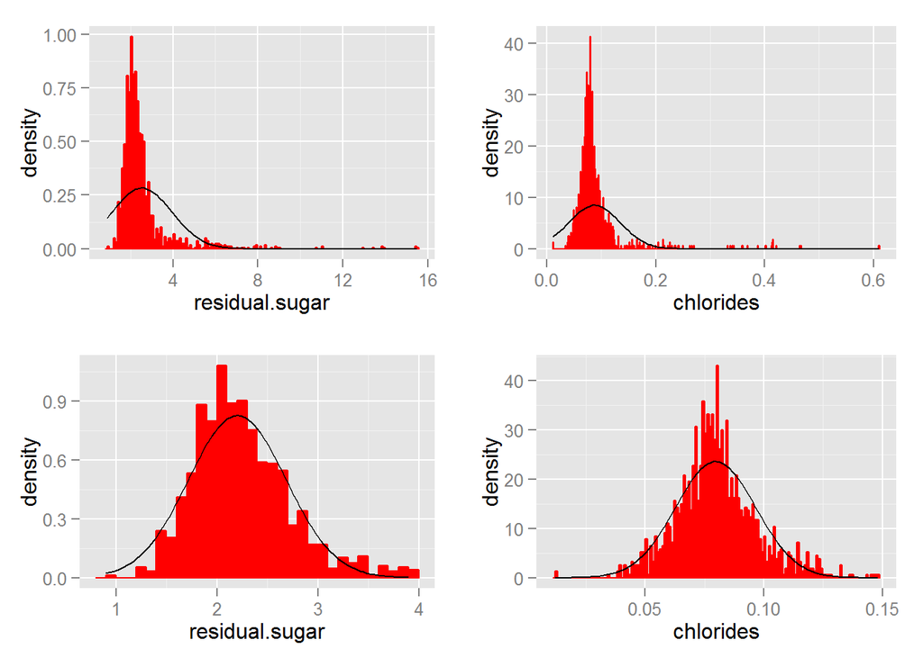

```
##    Min. 1st Qu.  Median    Mean 3rd Qu.    Max.
##    1.00    7.00   14.00   15.87   21.00   72.00
```

```
##    Min. 1st Qu.  Median    Mean 3rd Qu.    Max.
##    6.00   22.00   38.00   46.47   62.00  289.00
```

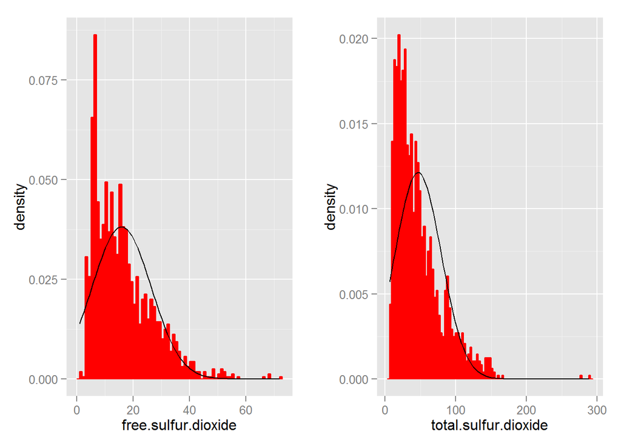

```
##    Min. 1st Qu.  Median    Mean 3rd Qu.    Max.
##  0.9901  0.9956  0.9968  0.9967  0.9978  1.0040
```

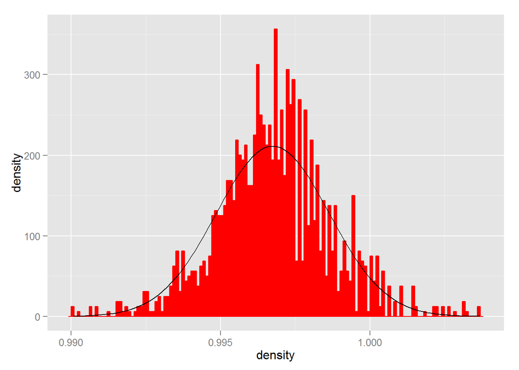

The distribution for “density has a normal appearence.

```
##    Min. 1st Qu.  Median    Mean 3rd Qu.    Max.
##  0.3300  0.5500  0.6200  0.6581  0.7300  2.0000
```

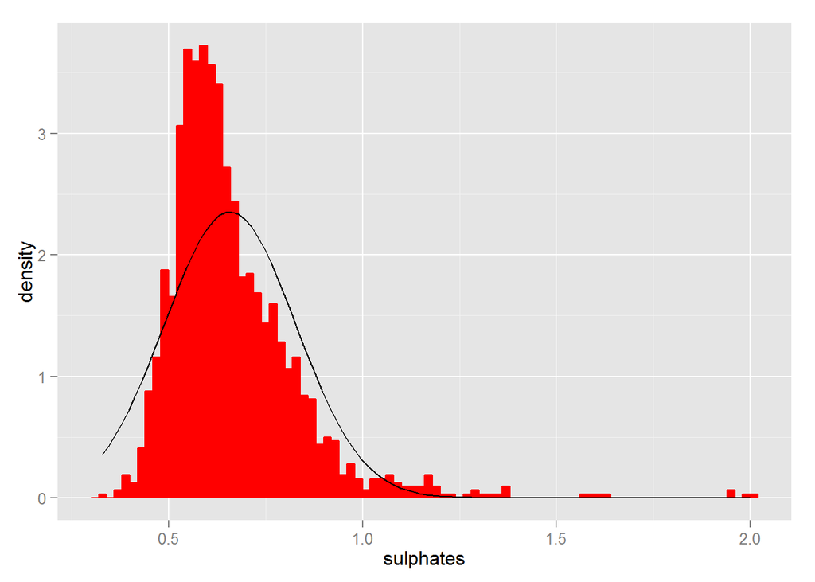

The distribution for “sulphates” has a normal appearence with outliers at the right side.

```
##    Min. 1st Qu.  Median    Mean 3rd Qu.    Max.
##    8.40    9.50   10.20   10.42   11.10   14.90
```

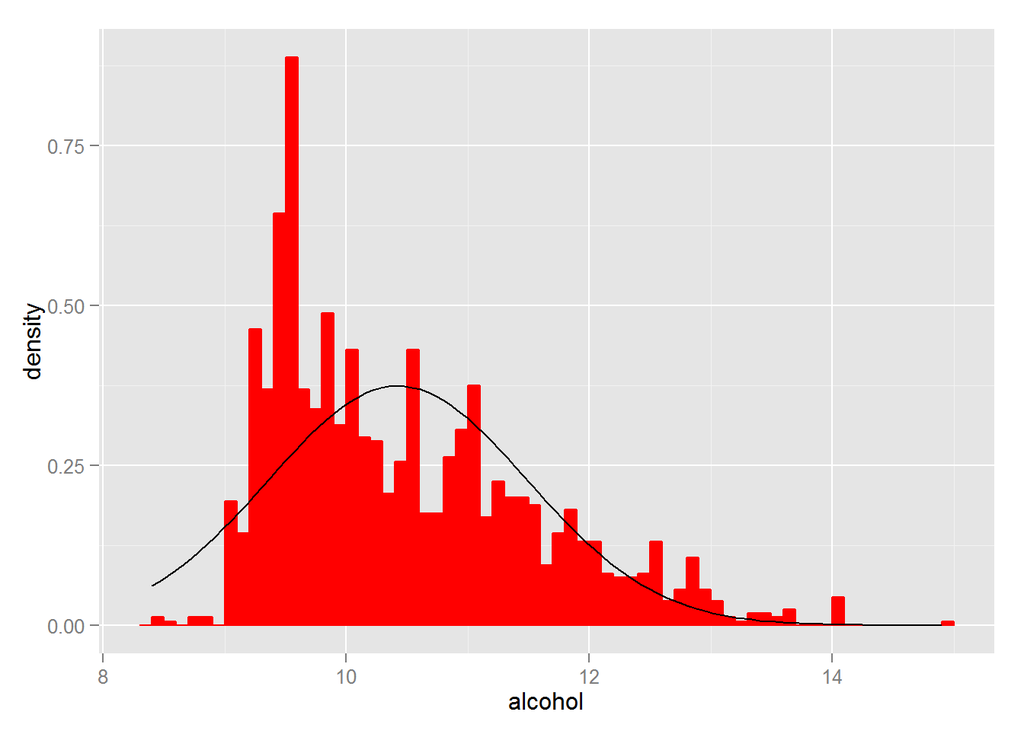

# Univariate Analysis

### What is the structure of your dataset?

This completed dataset contains 13 variables and 1599 observations. Variable “X” is indicator of observations. Integer variable “quality” is the median of wine qualities based on at least 3 wine experts evaluations; the rest 11 numeric variables are about the physical and chemical properties of wines.

### What is/are the main feature(s) of interest in your dataset?

Correlationship between quality and the 11 physical and chemical properties of wines is the main feature of interest in the dataset. However, quality is scored by personals, humans can not be as accurate as equilpments, and the final quality score is a median of more than three scores, so each quality level is very likely to cover a wide range of each physical and chemical properties of wine. The correlationship may be complicated.

### What other features in the dataset do you think will help support your

### investigation into your feature(s) of interest?

Some independent variables are actually related with eacher other, such as “pH” and “fixed.acidity”“,”volatile.acidity“”, “citric.acid”. These interior correlations could be used to cross-verify dataset.

### Did you create any new variables from existing variables in the dataset?

No.

### Of the features you investigated, were there any unusual distributions? Did

#### you perform any operations on the data to tidy, adjust, or change the form

#### of the data? If so, why did you do this?

“citric.acid” exhibits a rough uniform distribution, while others exhibit normal or skewed distributions. No operations was performed to tidy the dataset at this early stage.

# Bivariate Plots Section

For quick reviewing the correlationships between all 12 variables, a correlation table is produced with cor() function (ggplairs is tedius for this purpose).

|  | fixed.acidity | volatile.acidity | citric.acid | residual.sugar | chlorides | free.sulfur.dioxide | total.sulfur.dioxide | density | pH | sulphates | alcohol | quality |
| --- | --- | --- | --- | --- | --- | --- | --- | --- | --- | --- | --- | --- |
| fixed.acidity | NA | -0.2561309 | 0.6717034 | 0.1147767 | 0.0937052 | -0.1537942 | -0.1131814 | 0.6680473 | -0.6829782 | 0.1830057 | -0.0616683 | 0.1240516 |
| volatile.acidity | NA | NA | -0.5524957 | 0.0019179 | 0.0612978 | -0.0105038 | 0.0764700 | 0.0220262 | 0.2349373 | -0.2609867 | -0.2022880 | -0.3905578 |
| citric.acid | NA | NA | NA | 0.1435772 | 0.2038229 | -0.0609781 | 0.0355330 | 0.3649472 | -0.5419041 | 0.3127700 | 0.1099032 | 0.2263725 |
| residual.sugar | NA | NA | NA | NA | 0.0556095 | 0.1870490 | 0.2030279 | 0.3552834 | -0.0856524 | 0.0055271 | 0.0420754 | 0.0137316 |
| chlorides | NA | NA | NA | NA | NA | 0.0055621 | 0.0474005 | 0.2006323 | -0.2650261 | 0.3712605 | -0.2211405 | -0.1289066 |
| free.sulfur.dioxide | NA | NA | NA | NA | NA | NA | 0.6676665 | -0.0219458 | 0.0703775 | 0.0516576 | -0.0694084 | -0.0506561 |
| total.sulfur.dioxide | NA | NA | NA | NA | NA | NA | NA | 0.0712695 | -0.0664946 | 0.0429468 | -0.2056539 | -0.1851003 |
| density | NA | NA | NA | NA | NA | NA | NA | NA | -0.3416993 | 0.1485064 | -0.4961798 | -0.1749192 |
| pH | NA | NA | NA | NA | NA | NA | NA | NA | NA | -0.1966476 | 0.2056325 | -0.0577314 |
| sulphates | NA | NA | NA | NA | NA | NA | NA | NA | NA | NA | 0.0935948 | 0.2513971 |
| alcohol | NA | NA | NA | NA | NA | NA | NA | NA | NA | NA | NA | 0.4761663 |
| quality | NA | NA | NA | NA | NA | NA | NA | NA | NA | NA | NA | NA |

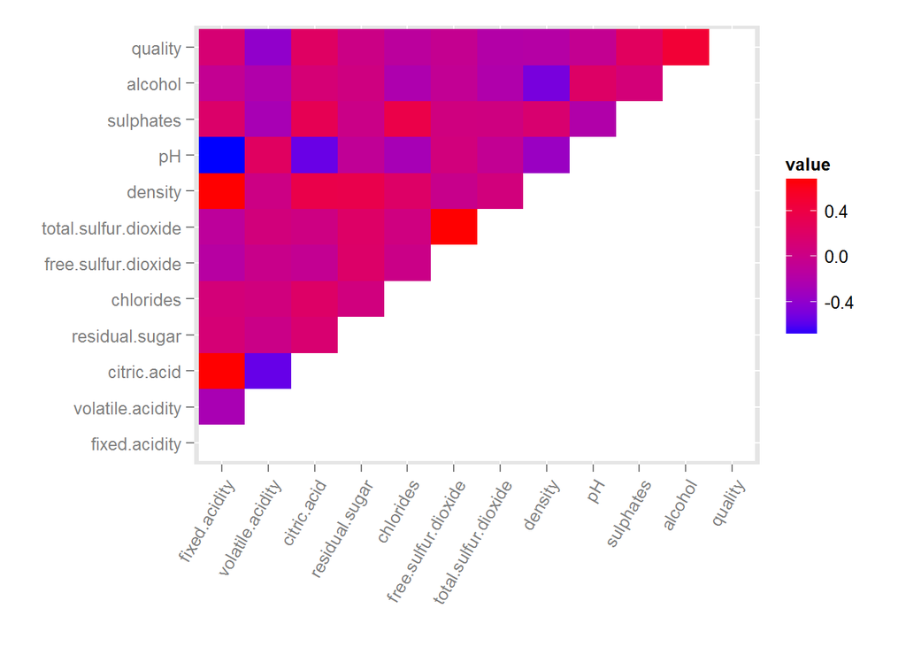

As expected, the 11 independent variables exhibit none to moderate correlations with the dependent variable “quality”. The variable having the highest correlation of 0.476 with “quality” is “alcohol”, the second is “volatile.acidity”. It is also confirmed that each quality score covers a wide range of each single physical and chemical properties of wine.

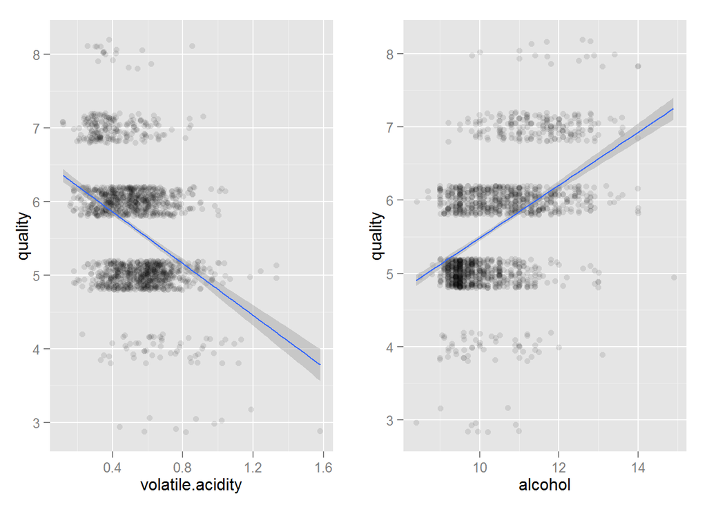

For a clear view, correlation plots of “alcohol” and “volatile.acidity” with “quality” are produced here.

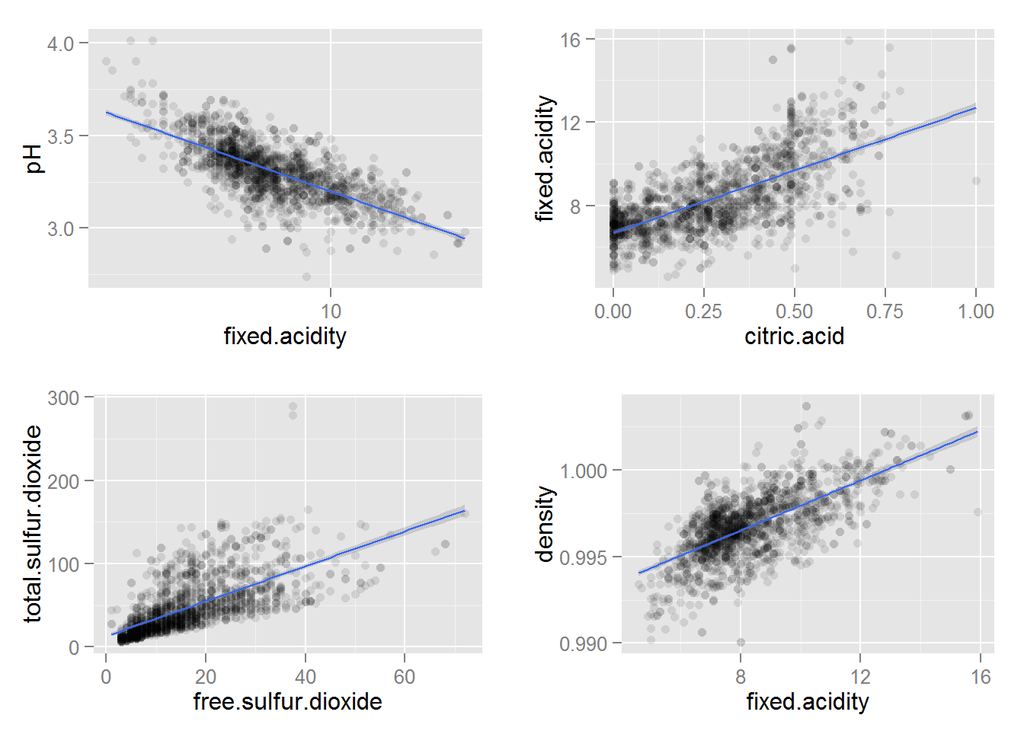

On the other hand, interior correlations do exist.

“fixed.acidity” and “citric.acid” have a strong positive correlation of 0.672, which also makes sense since ciitric acid is one the major acids in fruits. Indeed, “pH” does have a correlation of -0.542 with “citric.acid”.

“total.sulfur.dioxide” and “free.sulfur.dioxide” have a strong positive correlation of 0.668, because free form sulfur dioxide exists in equilibrium between dissolved sulfur dioxide and sulfite ion, e.g., the total sulfur dioxide.

“density” and “fixed.acidity” also have a strong positive correlation of 0.668, which makes sense because organic acids such as citric acid have higher density than water.

Because “quality” can be considered as categery variable, it is interesting to group the 11 independent variables according to “quality” level, then to check the relationships of means/medians of levels and coresponding quality levels.

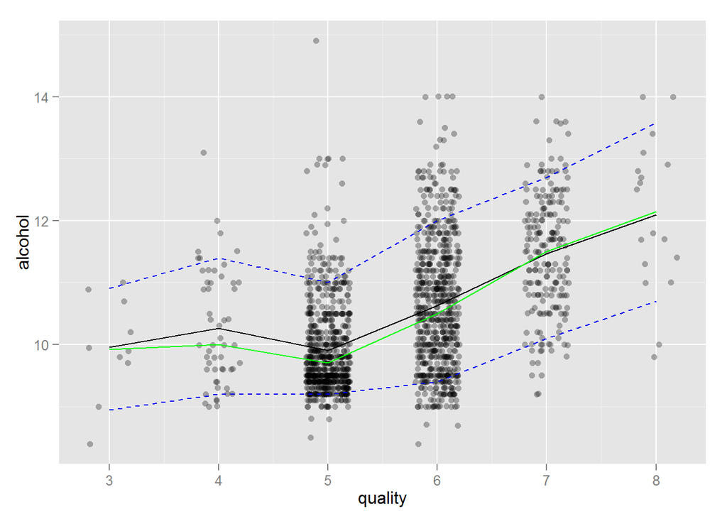

Very interestingly, the means/medians of “alcohol” of “quality” of levels exhibit strong linear correlation with “quality” levels. I therefore suspect that this observation is also true for other independent variables.

To prove this assuming, a new dataframe containing means of all 11 indenpendent variables grouped by “quality” levels is produced. A correlation table of “quality” v.s means of 11 indenpendent variables grouped by “quality” is generated accodingly and is compared with that of “quality” v.s. 11 indenpendent variables.

|  | property | means.by.group | raw |
| --- | --- | --- | --- |
| 9 | sulphates | 0.9858842 | 0.2513971 |
| 3 | citric.acid | 0.9724308 | 0.2263725 |
| 11 | volatile.acidity | -0.9491194 | -0.3905578 |
| 7 | pH | -0.9404445 | -0.0577314 |
| 2 | chlorides | -0.9201445 | -0.1289066 |
| 1 | alcohol | 0.9074534 | 0.4761663 |
| 4 | density | -0.8833802 | -0.1749192 |
| 5 | fixed.acidity | 0.6516203 | 0.1240516 |
| 6 | free.sulfur.dioxide | 0.3749704 | -0.0506561 |
| 8 | residual.sugar | -0.1457305 | 0.0137316 |
| 10 | total.sulfur.dioxide | 0.1187157 | -0.1851003 |

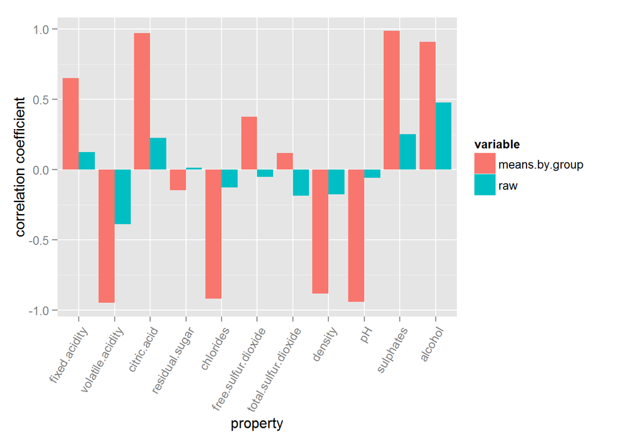

I can see that by grouping with “quality”, almost the means of indenpendent variables exhibit strong linear correlation with “quality” levels. The following analysis will concentrate in the top six variables, e.g., “alcohol”, “sulphates” ,“pH”, “chlorides”, “volatile.acidity” and “citric.acid”, with correlation coefficient greater than 0.9.

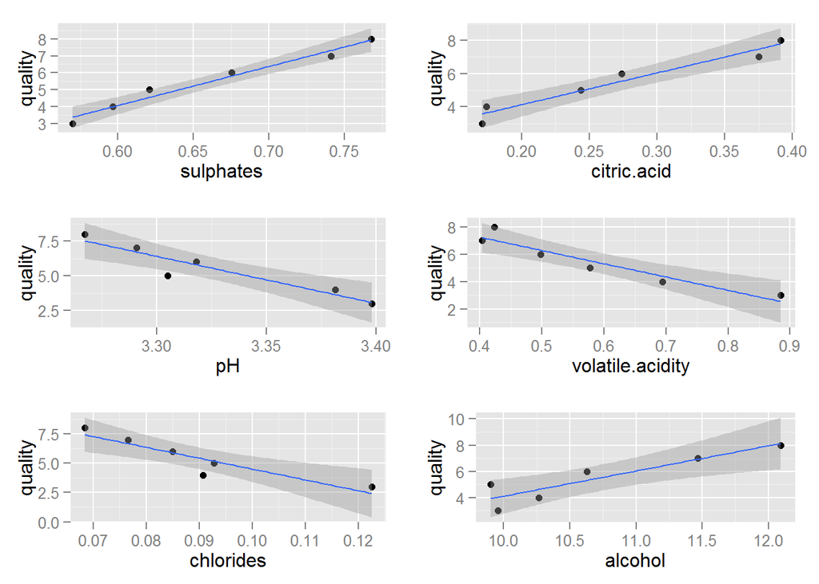

A similiar conclusion can be obtained with medians.

# Bivariate Analysis

### Talk about some of the relationships you observed in this part of the

### investigation. How did the feature(s) of interest vary with other features

### in the dataset?

“aclcohol” has modedate correlation with “quality”, others have weak or none correlations with “quality”. However, The means/medians of “aclcohol”, “sulphates” and “citric.acid” of each “quality” levels exhibit very strong positive linear correlation with “quality”, while means/medians of of “pH”, “chlorides” and “volatile.acidity” exhibit very strong negative linear correlation with “quality”.

### What was the strongest relationship you found?

“aclcohol” and “quality” have the strongest correlation between independent and dependent variables, while “pH” and “fixed.acidity” have the strongest interior correlation among independent variables.

# Multivariate Plots Section

As seen in the analysis above, in all 11 indenpendent variables,“alcohol” has the highest but moderate correlation coefficient of 0.476 to wine quality, while after being grouped by “quality”, the means/medians of “sulphates”,“pH”, “chlorides”, “volatile.acidity”, “citric.acid” and “alcohol” exhibit strong correlation with wine quality. Therefore I produced bivariate scatterplots of “alcohol” with other indenpendent vraibales to see if we can find stronger relationships between two indenpendent vraibales and the dependent vraibale “quality”,

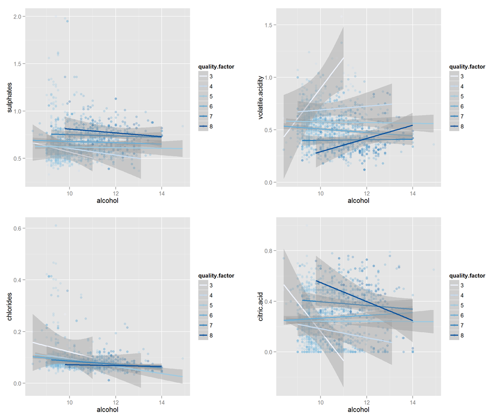

It is clear that spots of different qualities don’t show clear ranges. However, spots with quality under 5 and these above 5 do exhibit some aggregation. This observation implies that the dependent variable “quality” is not sensitive to the independent variables.

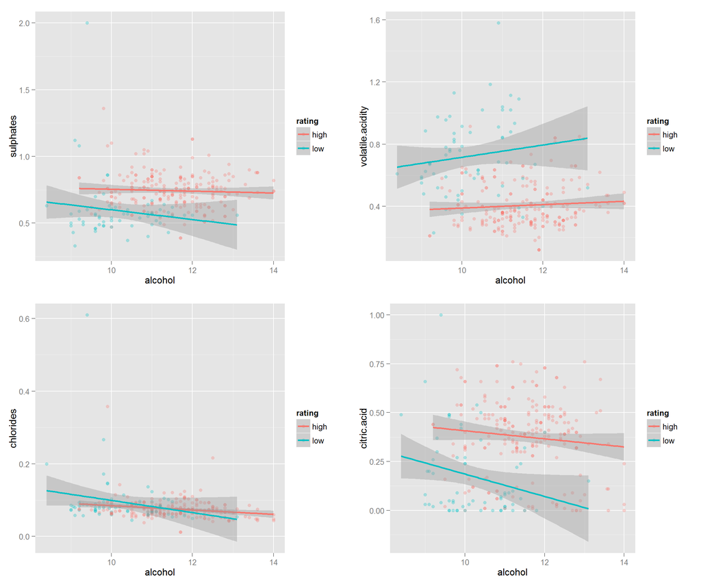

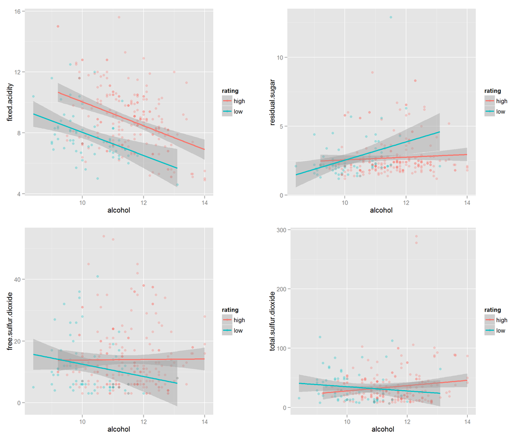

Bivariate scatterplots of “alcohol” with independent variables with week/none correlation coefficentss generally have weaker power to distinguish “low quality” from “high quality”.

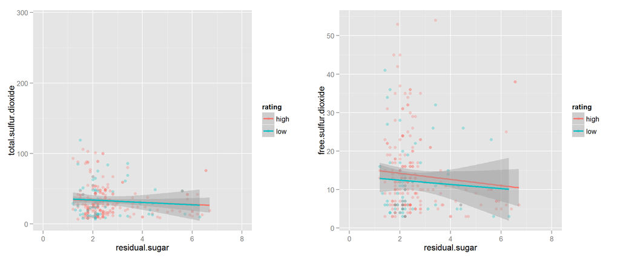

Bivariate scatterplots of independent variables with week/none correlation coefficents can’t distinguish “low quality” wines from “high quality” wines.

# Multivariate Analysis

### Talk about some of the relationships you observed in this part of the

### investigation. Were there features that strengthened each other in terms of

### looking at your feature(s) of interest?

Among all 11 independedt variables, “alcohol” plays a dominant but still weak role in correlations with the dependent variable of “quality”, while independedt variables of “sulphates”, “volatile.acidity” and “citric.acid” indeed strengthen the correlations.

### Were there any interesting or surprising interactions between features?

It is interesting to see that bivariate scatterplots with certain independent variables can distingusidh low/high end values of dependent variable. I guess it is either caused by wide mesurement error of wine quality, or there are other important wine pproperties such as fragrance are not included in this dataset.

### OPTIONAL: Did you create any models with your dataset? Discuss the strengths

### and limitations of your model.

No, I didn’t. The correlations between indenpendent variables and dependent variable are too weak, model based on current analysis is very likey meaningless . However, complex model might exist.

# Final Plots and Summary

### Plot One

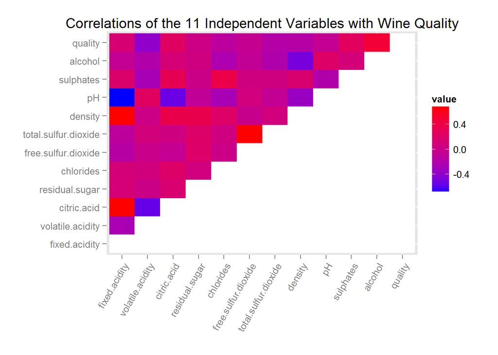

### Description One

One of the major purpose of performing EDA with dataset is to investigate the correlations among independent and dependent variables and provide a general map for advanced analysis such as regression modeling. Plot one demonstrates correlations of 11 indenpendent variables with wine quality. With Plot one, I can find that content of alcohol has a moderate but the highest correlation coeffeicient. volatile acidity, sulphates and citric acid follow with it. Other independent variables have weak or none correlations with wine quality. There are also strong interior correlations between “pH”/“fixed.acidity”, and “citric.acid”/“fixed.acidity”, “density”/“fixed.acidity”, and “total.sulfur.dioxide”/“free.sulfur.dioxide”. Therefore, my analysis can focus on the correlations between “quality” and “alcohol”.

### Plot Two

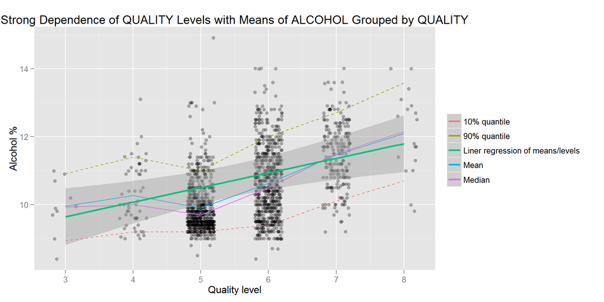

### Description Two

In bivariate analysis, simple scatter spots plots didn’t result much useful information about correlations between independent/dependent variables. The main reson could be the defination of wine quality, which may cover a range of indenpendent varibales distribution. Plot Two indeed reveales that if “alcohol” is grouped by “quality”, then means/medians of each sungroups have strong denpendence with “quality”.

### Plot Three

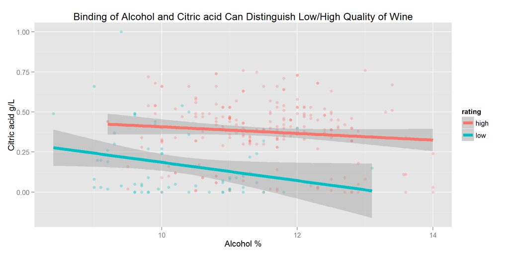

# Reflection

Through this exploratory data analysis, I identified key factors related with wine quality. Among them, alcohol content plays a major role, while acidity and sulphates also contribute. However, there must be many other factors that are related with wine quality. Altough graphs can illustrate relations between these factors and wine quality, more sophisticated statistic analysis are definetly needed to get a more consolid conslusions. On the other hand, wine quality is decided by many independent factors, it is apparently impossible to distinguish wine quality just by combinding of two factors. Combing of more independent variables is likely to give a better results, but this kind of analysis needs to be done in high dimesional space and is really beyond the scope of current project.

The hard part of this EDA comes from the poor correlations between independent/dependent variables. Although I have done data analysis for a long time in chmistry/drug areas, this is the first time I saw such a dataset. Really really confusing! Fortunately with google, I reallized that the wine quality is not like any other “quality” I met before and it is better to treat wine quality as level or categary variable rather than numeric variable. Actually If I carefully read the instruction I should find out that “quality” is the average of at least three evaluation results, this is an important clue but I just didnt pay enough attentions. Yes, dog sometimes must open eyes, nose may be misleading!